# M3: Hidden Markov Modeling for Accelerometer Data

Day 5 — Behavior Analysis Part 2

Animal Movement Analyses for Ecologists | SYSU Shenzhen, July 2026

30 July 2026

# Learning Objectives

By the end of this module you will be able to:

1. Fit a Hidden Markov model to accelerometer data
2. Assess irregulaties common to regularly sampled data
3. Calculate *Overall Dynamic Body Acceleration*
4. Fit multiple models to assess activity
5. Visualize output

**Packages used:** `momentuHMM`, `lubridate`, `tidyverse`, `dplyr`, `stringr`

# Introduction

> Many thanks to Dr. Dongmin Kim for assistance in developing this material

We’ve now learned the basics of fitting an HMM. We’ll now take this one step further, incorporating data from accelerometers fitted on maned wolves (*Chrysocyon brachyurus*) in Parque Nacional da Serra da Canastra in Brazil. In these analyses, we will focus on two individuals (male: ID 32866 - Juba; female: ID 32733 - Pacoca). Juba and Pacoca are a mating pair and Pacoca was pregnant when she was fitted with the accelerometer. Many thanks to Dr. Rosanna N. Moraes for making these data available for use.

```r
# Remove items from memory/clean your workspace
rm(list=ls())

# You may need to install these packages first
#install.packages('momentuHMM', 'lubridate', 'tidyverse', `dplyr`, `stringr`)

# Load libraries
library(momentuHMM)
library(lubridate)
library(tidyverse)
library(dplyr)
library(stringr)
```

## 1. Load Data

The accelerometer data used in this module are saved in a proprietary format (i.e., .binv2) from the manufacturer (Vectronics Aerospace). To load the data into [R](https://cran.r-project.org/), I first used the manufacturer’s software to convert them into an R-readable format (i.e., .csv).

```r
# Load data
# ID: 32733 - pacoca
pacoca <- read_csv("data/2022_pacoca_ACC.csv")

# ID: 32866 - juba
juba <- read_csv("data/2022_juba_ACC.csv")
```

## 2. Data Prep/Cleaning

These data do not have an ID column, with time organized in separate columns (UTC_Date and UTC_Time, respectively). “Year” is also omitted from the dataset. Because these columns are “character” columns, we need to join them together and then convert them to a date/time field.

```r
# Create ID for each animal
pacoca$ID <- "32733"
juba$ID <- "32866"

# Bind files together and create time field
data <- rbind(pacoca, juba)

# Create time field from available information in separate columns
data <- data %>%
  mutate(year = "2022",
         datetime = paste(year,
                          UTC_Date,
                          UTC_Time),
         time = parse_date_time(datetime,
                                 orders = "Y d-b HMS",
                                 tz = "UTC")) %>%
  dplyr::select(ID, time, x, y, z, temp)

# Remove unnecessary files
rm(pacoca, juba)
```

### 2.1 Dealing with Data Gaps

The base time interval between observations is 2 seconds (0.5 Hz). We still need to confirm that any missing observations were handled correctly.

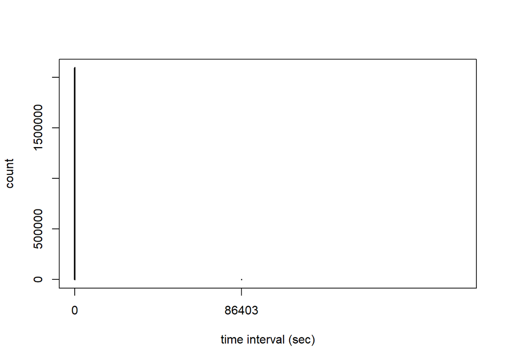

```r
# Table of time intervals in data
plot(table(diff(data$time)), xlim = c(0, 200000),
     xlab = "time interval (sec)", ylab = "count")
```

```r
# Look at time gaps
diff_data <- as.numeric(diff(data$time), units = "secs")
diff_data[diff_data > 2]
```

```
##   [1]     6     3 86403    11     4    11     3     4    12     3    12     3
##  [13]     3     4    11     4     3    11     3     4    12     3     3    12
##  [25]     4    11     3     3     4    11 86403    11     3     3 86404    12
##  [37] 86403     3     3    12 86404    11     3 86404    11     3 86404    12
##  [49]     3 86403    12 86404    11     3     3 86404    11 86404     3    12
##  [61] 86403    12     3     3 86405    11 86404    11     3 86404    12     7
##  [73] 86403     3    12     3 86404    11     3 86403    12 86403    12     3
##  [85] 86404    11 86404    11     3 86404    12     3 86403    12 86404    11
##  [97]     3 86404    11 86404     3    12 86403    12     3 86404    11 86404
## [109]    11     3 86404    12 86403     3    12 86404    11     3 86404    11
## [121]     4    12     3 86403    12     4     3    11     4    11     3     4
## [133]    12     3    12
```

Inspection of the sampling intervals indicates that most observations were collected at the expected interval (i.e., 2 seconds). However, we see some irregularities. These are common with accelerometer tags due to processing delays or device issues.

To correct for these issues, we created a function that generates a sequence that is the same length as our dataset. This allows us to automatically fill in the dataset with NAs where data do not exist.

```r
# Function to pad each split track to a regular 2-second time series
pad_time_series <- function(df, interval = 2){
  # Create a full (regular) time sequence for the entire tracking period (min and max)
  full_time <- data.frame(
    time = seq(
      from = min(df$time),
      to   = max(df$time),
      by   = interval
    )
  )

  # Merge observations together.
  # This will automatically put a NA in the time series where a record previously did not exist
  full_data <- left_join(
    full_time,
    df,
    by = "time"
  )

  # restore ID for inserted NA rows
  full_data$ID <- unique(df$ID)

  return(full_data)
}

# Apply padding to each track, split by the ID we created.
data <- data %>%
  group_split(ID) %>%
  map_dfr(pad_time_series)

# check the data summary
summary(data)
```

```
##       time                             ID                  x
##  Min.   :2022-08-17 00:00:00.00   Length:2106032     Min.   :-1.4
##  1st Qu.:2022-08-23 02:15:07.75   Class :character   1st Qu.:-0.5
##  Median :2022-08-29 04:30:15.50   Mode  :character   Median :-0.2
##  Mean   :2022-08-29 04:30:15.50                      Mean   :-0.2
##  3rd Qu.:2022-09-04 06:45:23.25                      3rd Qu.: 0.0
##  Max.   :2022-09-10 09:00:33.00                      Max.   : 1.2
##                                                      NA's   :1015493
##        y                 z                temp
##  Min.   :-1.3      Min.   :-1.1      Min.   :10.0
##  1st Qu.:-0.5      1st Qu.:-0.8      1st Qu.:19.0
##  Median :-0.2      Median :-0.7      Median :22.0
##  Mean   :-0.1      Mean   :-0.5      Mean   :22.7
##  3rd Qu.: 0.3      3rd Qu.:-0.3      3rd Qu.:27.0
##  Max.   : 1.2      Max.   : 1.4      Max.   :46.0
##  NA's   :1015493   NA's   :1015493   NA's   :1015493
```

### 2.2 Calculate ODBA

Unlike GPS data, activity data do not include location information such as coordinates (e.g., Easting/Northing or latitude/longitude). Instead, activity data capture movement using proxy variables. In our data, these activity data are labeled as ‘x’, ‘y’, and ‘z’, measuring motion along three dimensions (X, Y, and Z - surge, sway, and heave).

These three measurements are often combined into a single summary metric called *Overall Dynamic Body Acceleration* or *ODBA*, representing the overall intensity of movement. ODBA is commonly used as an indicator of activity or energy expenditure.

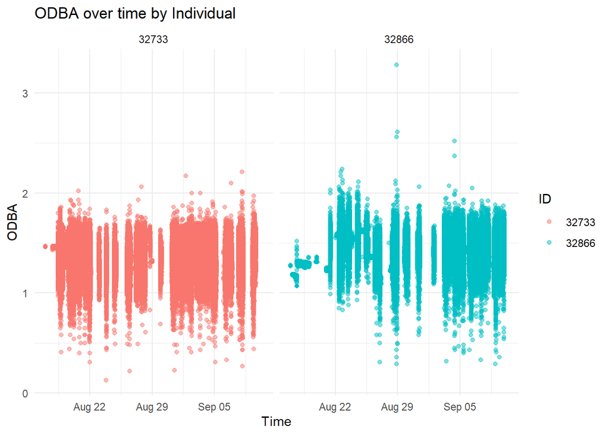

```r
## use a single summary activity variable - ODBA
data$ODBA <- rowSums(abs(data[, c("x", "y", "z")]))

# Select the fields of interest
data <- data %>%
  dplyr::select(ID, time, temp, ODBA)

# Plot
plot.ODBA <- ggplot(data, aes(x = time, y = ODBA, color = ID)) +
  geom_point(alpha = 0.5) +
  facet_wrap(~ ID) +
  theme_minimal() +
  labs(
    x = "Time",
    y = "ODBA",
    title = "ODBA over time by Individual"
  )

# Print to view the plot
plot.ODBA
```

```r
# Clean up unneeded objects
rm(diff_data)
```

## 3. The MomentuHMM Workflow

The data are now ready to be used in [momentuHMM](https://cran.r-project.org/web/packages/momentuHMM/index.html), following a similar set of steps that we are now familiar with, inclusive of the covariate temperature.

### 3.1 Data preparation

Note that we do not handle the location data like the GPS example. Here, we set the ‘coordNames’ argument to NULL within the function ‘prepData’ since location data are not included with the accelerometer.

```r
# To have this run quicker, let's analyze 10% of the data, selected from the tail of the dataset
data <- data %>%
  group_by(ID) %>%
  slice_tail(prop = 0.10)

# Summarize dataset being used
# data %>%
#   group_by(ID) %>%
#   summarise(n_na = sum(is.na(ODBA)),
#             n_records = n(),
#             Prop = n_na / n_records)

# Plot
# plot.ODBA <- ggplot(data, aes(x = time, y = ODBA, color = ID)) +
#   geom_point(alpha = 0.5) +
#   facet_wrap(~ ID) +
#   theme_minimal() +
#   labs(
#     x = "Time",
#     y = "ODBA",
#     title = "ODBA over time by Individual"
#   )
#
# # Print to view the plot
# plot.ODBA

# Prepare data for HMM
data_hmm <- prepData(data, coordNames = NULL, covNames = "temp")
```

### 3.2 Setting Model Parameters

[MomentuHMM](https://cran.r-project.org/web/packages/momentuHMM/index.html) is quite flexible and can handle multiple datastreams, including GPS data for coarse-scale movements. Here, we will focus intently on the activity data only, using the function `fitHMM()` to fit models as we used previously.

We are interested in two states, State 1 or *‘Low Activity’* and State 2 or *‘High Activity’*. To get started, we need to specify two things:

1. Observation distributions - Each observed variable needs a probability distribution to define each activity state. ODBA is continuous and strictly positive, allowing us to once again use the gamma distribution.
2. Initial parameter values - The `fitHMM()` function uses numerical optimization to find maximum likelihood estimates. The optimization requires a starting point. For a gamma distribution, each state requires two parameters. As before, these are: (1) mean ($\bar{x}$) of the gamma and (2) standard deviation ($\sigma{x}$) of the gamma for each state.

Please once again refer to the [moveHMM](https://cran.r-project.org/web/packages/moveHMM/index.html) guide on selecting initial parameter values, as this can be very tricky: [A short guide to choosing initial parameter values for the estimation in moveHMM](https://cran.r-project.org/web/packages/moveHMM/vignettes/moveHMM-starting-values.pdf).

```r
# Observation distribution for ODBA
# ODBA is continuous and strictly positive, so a gamma distribution is appropriate.
# Missing ODBA values (created during temporal regularization) are retained in data_hmm
# and handled by momentuHMM.
dist <- list(ODBA = "gamma")

# Initial parameter values (Par0)
# Remove only missing values temporarily for calculating starting parameters.
# The original NA values remain in data_hmm for HMM fitting.
ODBA_obs <- data$ODBA[!is.na(data$ODBA)]

# Define initial means for the two activity states
# State 1: low-activity state
# Initialized using the lower half of observed ODBA values.
mu1 <- mean(ODBA_obs[ODBA_obs <= median(ODBA_obs)])

# State 2: high-activity state
# Initialized using the upper quartile of observed ODBA values.
mu2 <- mean(ODBA_obs[ODBA_obs >= quantile(ODBA_obs, 0.75)])

# Define initial standard deviations for each state
# These values describe the expected variability within each activity state.
# Small positive values are required because gamma parameters cannot be zero.
sd1 <- sd(ODBA_obs[ODBA_obs <= median(ODBA_obs)])
sd2 <- sd(ODBA_obs[ODBA_obs >= quantile(ODBA_obs, 0.75)])

# Combine into Par0
# The order is important: c(mu1, mu2, sd1, sd2)
Par0_2s <- list(
  ODBA = c(mu1, mu2, sd1, sd2)
)
```

### 3.3 Model Fitting

Now we will fit a 2 state model.

```r
# Fit a 2-state HMM
# Missing ODBA observations from the regularized time series remain as NA and are handled internally by momentuHMM.
hmm1 <- fitHMM(data_hmm,
               nbStates = 2,
               dist = dist,
               Par0 = Par0_2s)

# Print parameter estimates
hmm1
```

```
## Value of the maximum log-likelihood: 70134.03
##
##
## ODBA parameters:
## ----------------
##        state 1  state 2
## mean 1.2841885 1.495276
## sd   0.1211982 0.105039
##
## Regression coeffs for the transition probabilities:
## ---------------------------------------------------
##                1 -> 2    2 -> 1
## (Intercept) -3.902987 -4.319907
##
## Transition probability matrix:
## ------------------------------
##            state 1   state 2
## state 1 0.98021770 0.0197823
## state 2 0.01312653 0.9868735
##
## Initial distribution:
## ---------------------
##   state 1   state 2
## 0.5002273 0.4997727
```

### 3.4 Model Visualization

Similar to previous exercises, we see review summary statistics and regression coefficients providing from the model output. We can also plot the estimated distributions to visualize the findings.

```
## Decoding state sequence... DONE
```

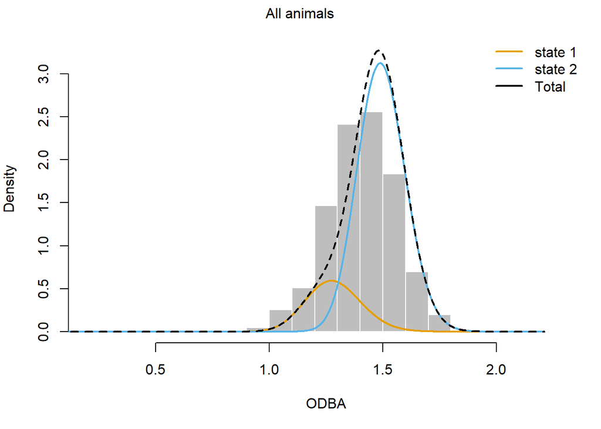

```r
# Plot estimated distributions and state-coloured tracks
plot(hmm1, ask = FALSE)
```

We can also estimate the most likely state sequence for a fitted model with the ‘viterbi’ algorithm.

```r
# get most likely sequence of states
head(viterbi(hmm1))
```

```
## [1] 2 2 2 2 2 2
```

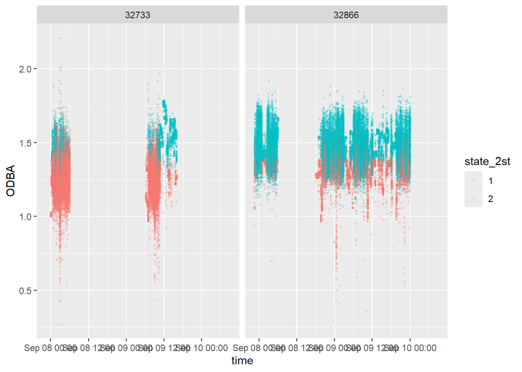

```r
# save most likely state sequence from 2-state model
data_hmm$state_2st <- factor(viterbi(hmm1))

# plot OBDA over time, colored by states
ggplot(data_hmm, aes(x = time, y = ODBA, col = state_2st, group = ID))+
  geom_point(size = 0.5, alpha = 0.2)+
  facet_wrap(~ID)
```

### 3.5 Model Formulation: Covariates

Now, following the same structure as previously, we will include the temperature measurements collected by the tag at each time of observation. Here, we aim to answer whether temperature impacts maned wolf activity patterns. To do so, we’ll estimate the effect of temperature on the transition probabilities.

```r
# Fit 2-state HMM with temperature covariate
hmm2 <- fitHMM(data_hmm,
               nbStates = 2,
               dist = dist,
               Par0 = Par0_2s,
               formula = ~ temp)

# show summary of model 2
hmm2
```

```
## Value of the maximum log-likelihood: 70227.85
##
##
## ODBA parameters:
## ----------------
##        state 1   state 2
## mean 1.2850419 1.4965571
## sd   0.1208717 0.1044625
##
## Regression coeffs for the transition probabilities:
## ---------------------------------------------------
##                  1 -> 2      2 -> 1
## (Intercept) -1.80066503 -2.08596786
## temp        -0.09210685 -0.09560976
##
## Transition probability matrix (based on mean covariate values):
## ---------------------------------------------------------------
##            state 1    state 2
## state 1 0.97995543 0.02004457
## state 2 0.01400421 0.98599579
##
## Initial distribution:
## ---------------------
##   state 1   state 2
## 0.5111613 0.4888387
```

Visualize the stationary state probabilities as a function of the temperature covariate.

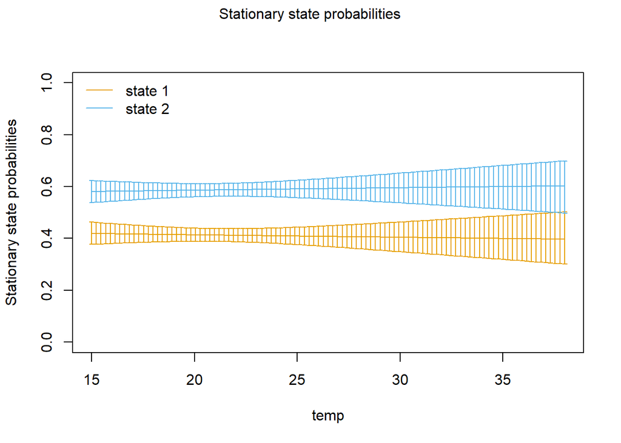

```r
# plot stationary state probabilities as functions of temperature
plotStationary(hmm2,
               plotCI = TRUE)
```

### 3.6 Model Comparison

We then use the function `AIC()` for model selection, comparing the model without the covariate versus the model with the temperature covariate.

```r
# Compare models using AIC
AIC(hmm1,
    hmm2)
```

```
##   Model       AIC
## 1  hmm2 -140437.7
## 2  hmm1 -140254.1
```

These results indicate that model 2, inclusive of temperature, has more statistical support. We could also explore model fit by plotting pseudo residuals `plotPR()` function on our model output.

# Exercise: Apply to your own data

If you have accelerometer data, try to apply these lesson materials to your own data. Make sure you investigate the quality of your data closely and assess the percentage of time that your animal spends in one activity compared to another. Otherwise, please study this lecture to increase your understanding of key concepts. The package also contains a variety of other functions that are useful as you get more deeply involved with fitting HMMs.

## Key functions reference

| Function | Package | Purpose |
| --- | --- | --- |
| `parse_date_time()` | `lubridate` | Convert combined date/time strings to POSIXct timestamps |
| `group_split()` | `dplyr` | Split data frame by ID into list of data frames |
| `map_dfr()` | `purrr` | Apply padding function to each track and row‑bind results |
| `str_remove()` | `stringr` | Remove burst suffix from ID field |
| `prepData()` | `momentuHMM` | Prepare movement data for HMM fitting (compute steps, angles, covariates) |
| `fitHMM()` | `momentuHMM` | Fit hidden Markov models to movement data |
| `viterbi()` | `momentuHMM` | Decode most likely state sequence |
| `plotStationary()` | `momentuHMM` | Plot stationary state probabilities vs covariates |

*Next:* **Day 5 — CTMM Error** — Now, we’ll return to CTMM and discuss the errors inherent in your positional data.